# Correlation_VIF

### Methodology

A correlation analysis was conducted on a dietary dataset to understand the relationships between various dietary variables. The dataset was sourced from an Excel file, and the following steps were performed:

1. **Data Preparation:** The dataset was loaded, and non-numeric values were converted to `NaN` to ensure all data could be numerically analyzed. The first column, assumed to contain non-relevant data, was excluded from the analysis.
2. **Correlation Analysis:** The Pearson correlation coefficients between all pairs of variables were computed. Due to the large number of variables, the analysis was conducted in manageable chunks of 20 columns each.
3. **Visualization:** For each subset of 20 variables, a heatmap was generated to visualize the correlation matrix. This approach facilitated the identification of significant correlations and patterns within smaller groups of variables, ensuring clarity and ease of interpretation.

The correlation matrices were visualized using Seaborn's heatmap function, providing an intuitive and comprehensive view of the interrelationships among the dietary variables.

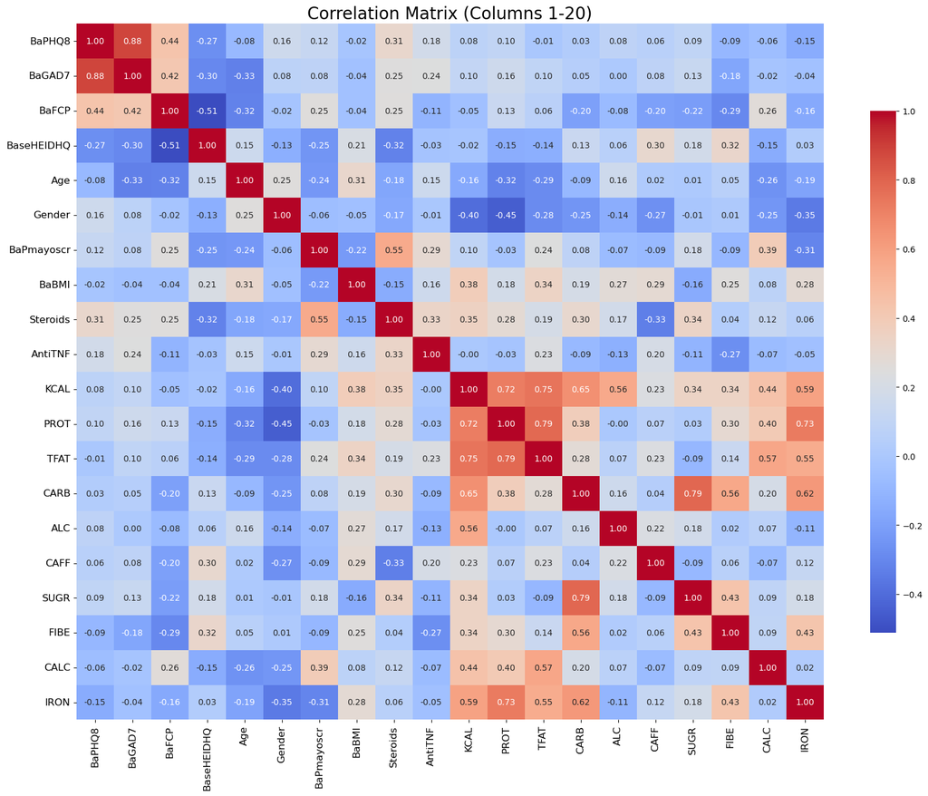

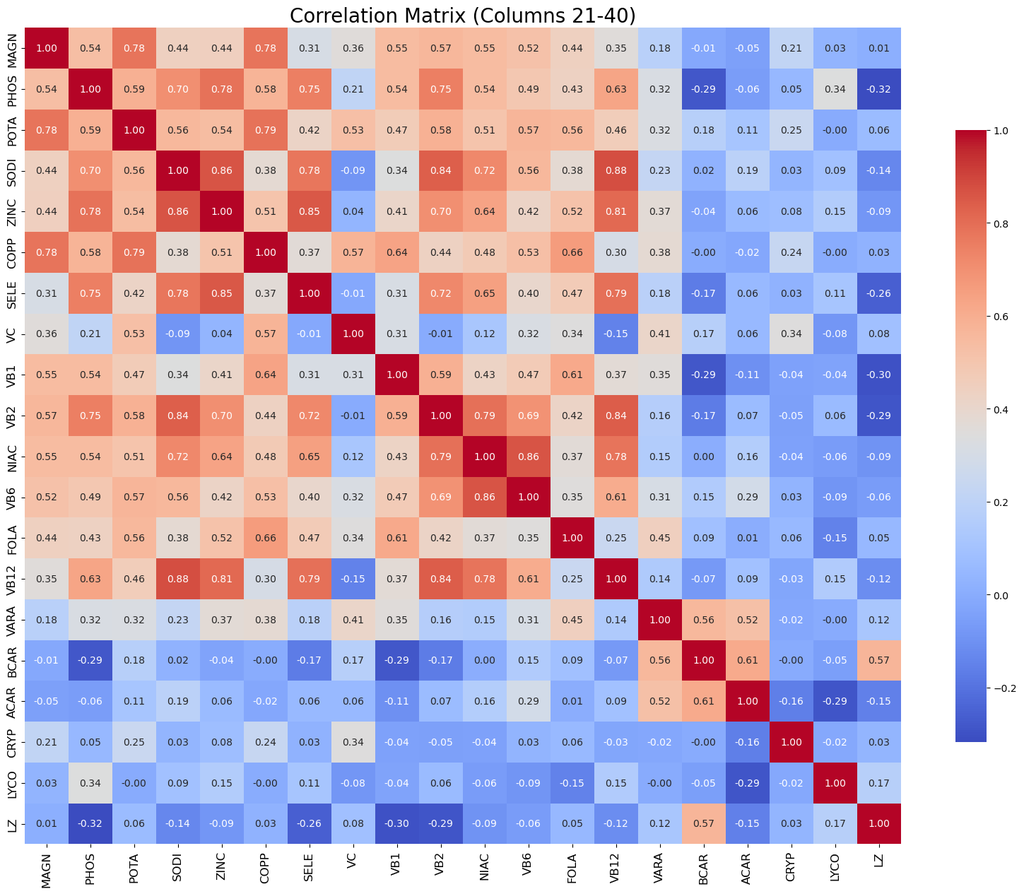

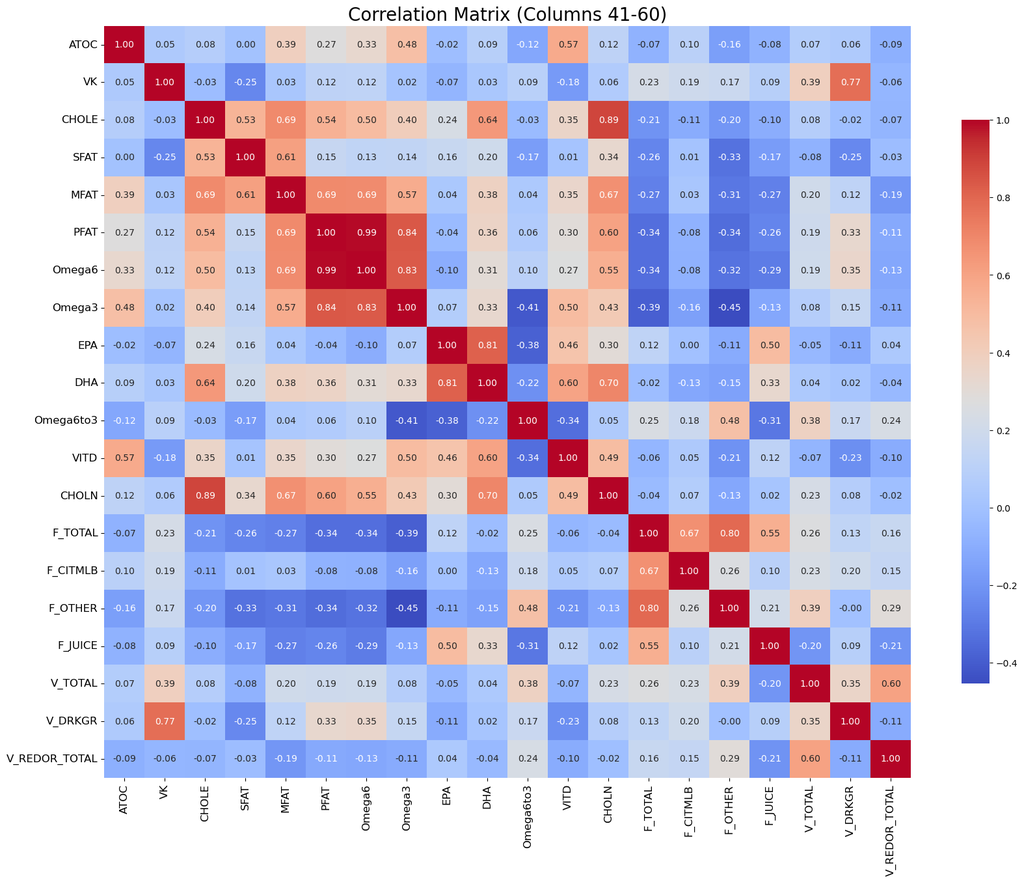

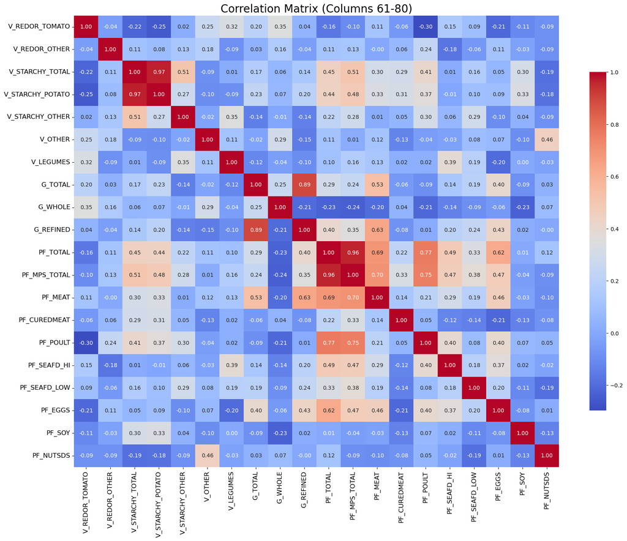

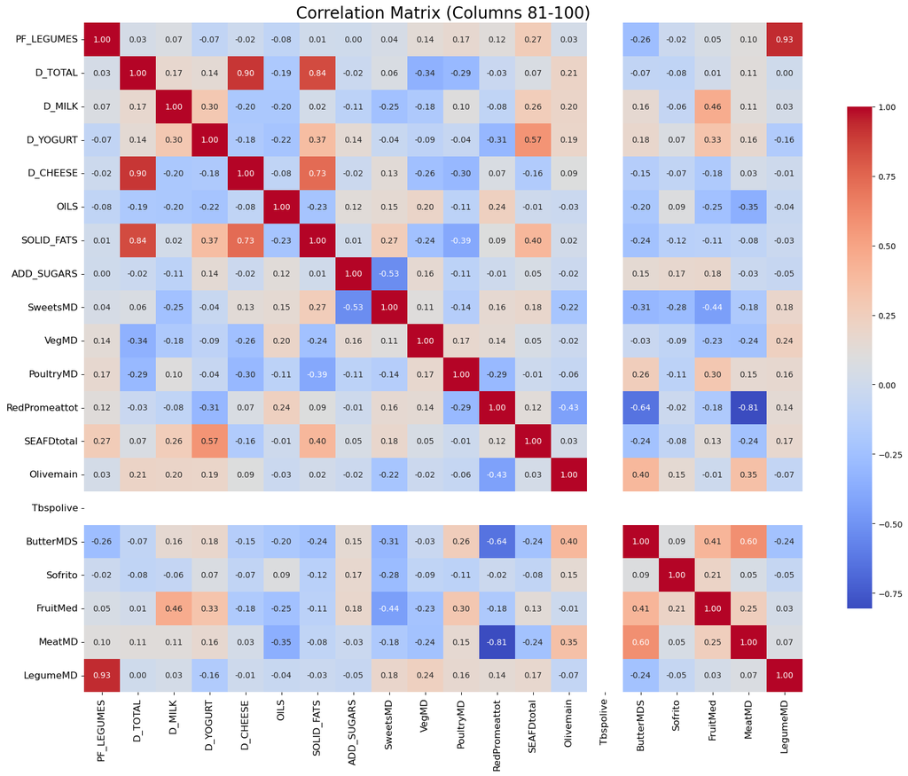

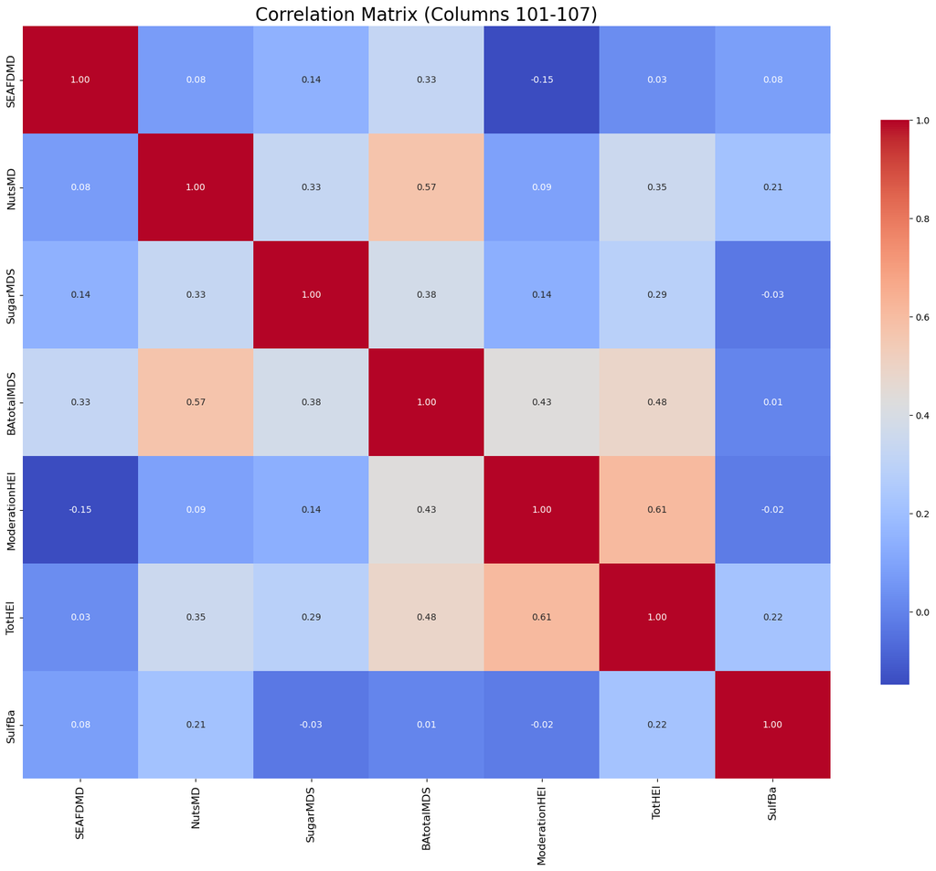

```python
import pandas as pd
import numpy as np
import matplotlib.pyplot as plt
import seaborn as sns

# Load the data
df = pd.read_excel('/Users/nijat/Downloads/Diet.xlsx')

# Convert non-numeric values to NaN
df = df.apply(pd.to_numeric, errors='coerce')

# Exclude the first column
df = df.iloc[:, 1:]

# Function to plot correlation matrix for a subset of columns
def plot_correlation_matrix(subset_columns, df, title_suffix):
    correlation_matrix_subset = df[subset_columns].corr()
    plt.figure(figsize=(20, 15))
    sns.heatmap(correlation_matrix_subset, annot=True, fmt=".2f", cmap="coolwarm", annot_kws={"size": 10}, cbar_kws={"shrink": 0.75})
    plt.title(f'Correlation Matrix {title_suffix}', size=20)
    plt.xticks(rotation=90, size=12)
    plt.yticks(size=12)
    plt.show()

# Get the list of columns
columns = df.columns

# Plot in chunks of 20 columns
for i in range(0, len(columns), 20):
    subset_columns = columns[i:i+20]
    plot_correlation_matrix(subset_columns, df, f'(Columns {i+1}-{min(i+20, len(columns))})')
```

A collinearity analysis was conducted on a dietary dataset to identify highly correlated variables. The dataset was sourced from an Excel file, and the following steps were performed:

1. **Correlation Analysis:** The Pearson correlation coefficients between all pairs of variables were computed to form a correlation matrix. A threshold of 0.8 was defined to identify high collinearity.
2. **Identification of Collinear Variables:** For each variable, highly collinear variables (with correlation coefficients greater than the threshold) were listed. The variable itself was excluded from its list of collinear variables to avoid trivial self-correlation.
3. **Sorting and Displaying Results:** The collinear variables were sorted by the number of collinear pairs in descending order, and the results were displayed to highlight the variables with the highest collinearity.

This process provided a clear identification of highly correlated variables, facilitating further analysis and interpretation of the dietary data.

```python
path = '/Users/nijat/Desktop/Diet.xlsx'
# Load the data
df = pd.read_excel(path)

# Convert non-numeric values to NaN and exclude the first column
df = df.apply(pd.to_numeric, errors='coerce').iloc[:, 1:]

# Drop rows with missing values for this analysis
df = df.dropna()

# Calculate the correlation matrix
correlation_matrix = df.corr()

# Define the threshold for high collinearity
high_collinear_threshold = 0.8

# Find and list collinear variables for each variable
collinear_vars = {}

for col in correlation_matrix.columns:
    collinear_vars[col] = correlation_matrix[col][correlation_matrix[col].abs() > high_collinear_threshold].index.tolist()
    # Remove the variable itself from the list if present
    if col in collinear_vars[col]:
        collinear_vars[col].remove(col)

# Sort collinear variables by the number of collinear pairs (descending)
sorted_collinear_vars = sorted(collinear_vars.items(), key=lambda x: len(x[1]), reverse=True)

# Display the results
for col, collinear in sorted_collinear_vars:
    print(f"Variables collinear with {col}:")
    print(collinear)
    print("\n")
```

```
Variables collinear with ZINC:
['PROT', 'TFAT', 'IRON', 'PHOS', 'SODI', 'SELE', 'VB12', 'MFAT', 'CHOLN', 'PF_TOTAL', 'PF_MPS_TOTAL', 'PF_MEAT']


Variables collinear with PROT:
['IRON', 'PHOS', 'SODI', 'ZINC', 'SELE', 'VB2', 'NIAC', 'VB12', 'CHOLN', 'PF_TOTAL', 'PF_MPS_TOTAL']


Variables collinear with SELE:
['PROT', 'TFAT', 'IRON', 'ZINC', 'VB12', 'CHOLE', 'MFAT', 'CHOLN', 'PF_TOTAL', 'PF_MPS_TOTAL']


Variables collinear with VB12:
['PROT', 'SODI', 'ZINC', 'SELE', 'VB2', 'PF_TOTAL', 'PF_MPS_TOTAL', 'PF_MEAT', 'RedPromeattot', 'MeatMD']


Variables collinear with PF_TOTAL:
['PROT', 'ZINC', 'SELE', 'NIAC', 'VB12', 'CHOLE', 'CHOLN', 'PF_MPS_TOTAL']


Variables collinear with CHOLN:
['PROT', 'IRON', 'ZINC', 'SELE', 'CHOLE', 'PF_TOTAL', 'PF_MPS_TOTAL']


Variables collinear with PF_MPS_TOTAL:
['PROT', 'ZINC', 'SELE', 'NIAC', 'VB12', 'CHOLN', 'PF_TOTAL']


Variables collinear with SODI:
['PROT', 'ZINC', 'VB2', 'VB12', 'PF_MEAT', 'RedPromeattot']


Variables collinear with IRON:
['PROT', 'ZINC', 'SELE', 'FOLA', 'CHOLN']


Variables collinear with VB2:
['PROT', 'SODI', 'VB1', 'NIAC', 'VB12']


```

[output cut: 371 more lines]

```

Variables collinear with BAtotalMDS:
[]


Variables collinear with ModerationHEI:
[]


Variables collinear with TotHEI:
[]


Variables collinear with SulfBa:
[]
```

A list of non-colinear variables were selected and the analyis above was repeated to show that varibles selected are not colinear with each other.

```python
# Load the data
df = pd.read_excel(path)
# Convert non-numeric values to NaN and exclude the first column
df = df.apply(pd.to_numeric, errors='coerce').iloc[:, 1:]

# Define list of non-collinear variables
non_collinear_variables = [
    "PROT", "PFAT", "DHA", "CARB", "D_TOTAL", "SFAT", "V_LEGUMES", "MeatMD", "BaPHQ8",
    "VB1", "VB6", "F_TOTAL", "V_TOTAL", "G_TOTAL", "BaFCP", "BaseHEIDHQ", "Age", "Gender",
    "BaPmayoscr", "BaBMI", "Steroids", "AntiTNF", "KCAL", "ALC", "CAFF", "FIBE", "MAGN", "VC",
    "VARA", "BCAR", "ACAR", "CRYP", "LYCO", "ATOC", "Omega6to3", "VITD", "F_CITMLB", "F_OTHER",
    "F_JUICE", "V_REDOR_TOTAL", "V_REDOR_TOMATO", "V_REDOR_OTHER", "V_STARCHY_OTHER", "G_WHOLE",
    "PF_CUREDMEAT", "PF_POULT", "PF_SOY", "PF_NUTSDS", "D_YOGURT", "D_CHEESE", "SweetsMD",
    "PoultryMD", "Olivemain", "ButterMDS", "Sofrito", "NutsMD", "SugarMDS",
    "BAtotalMDS", "ModerationHEI", "TotHEI", "SulfBa"
]

# Select columns from the non-collinear variables list
df = df[non_collinear_variables]

# Drop rows with missing values for this analysis
df = df.dropna()

# Calculate the correlation matrix
correlation_matrix = df.corr()

# Define the threshold for high collinearity
high_collinear_threshold = 0.8

# Find and list collinear variables for each variable
collinear_vars = {}

for col in correlation_matrix.columns:
    collinear_vars[col] = correlation_matrix[col][correlation_matrix[col].abs() > high_collinear_threshold].index.tolist()
    # Remove the variable itself from the list if present
    if col in collinear_vars[col]:
        collinear_vars[col].remove(col)

# Sort collinear variables by the number of collinear pairs (descending)
sorted_collinear_vars = sorted(collinear_vars.items(), key=lambda x: len(x[1]), reverse=True)

# Display the results
for col, collinear in sorted_collinear_vars:
    print(f"Variables collinear with {col}:")
    print(collinear)
    print("\n")
```

```
Variables collinear with PROT:
[]


Variables collinear with PFAT:
[]


Variables collinear with DHA:
[]


Variables collinear with CARB:
[]


Variables collinear with D_TOTAL:
[]


Variables collinear with SFAT:
[]


Variables collinear with V_LEGUMES:
[]


Variables collinear with MeatMD:
[]


Variables collinear with BaPHQ8:
[]


Variables collinear with VB1:
[]


```

[output cut: 187 more lines]

```

Variables collinear with BAtotalMDS:
[]


Variables collinear with ModerationHEI:
[]


Variables collinear with TotHEI:
[]


Variables collinear with SulfBa:
[]
```

A variance inflation factor (VIF) analysis was conducted on a dietary dataset to identify and select variables with minimal multicollinearity. The dataset was sourced from an Excel file, and the following steps were performed:

1. **Data Preparation:** The dataset was preprocessed to ensure all values were numeric and to handle any missing data appropriately. This included converting non-numeric values to NaN and dropping rows with missing values.
2. **Candidate Variable Selection:** A predefined list of potential variables was created based on the results of an initial collinearity analysis. This list included relevant dietary factors, with some collinear variables already removed. Despite the initial removal of collinear variables, a further VIF analysis was necessary to ensure that the remaining variables did not exhibit significant multicollinearity. The VIF measures the impact of collinearity among the variables in a regression model, which can affect the stability and interpretability of the model's coefficients.
3. **Iterative VIF Calculation:** To ensure the selection of variables with minimal multicollinearity, an iterative approach was used:
   - Each variable from the candidate list was added one by one to a set of initially selected variables.
   - For each iteration, the VIF was calculated for the current set of variables.
   - If the VIFs of all variables in the current set remained below the threshold of 10, the variable was retained.
   - If adding a variable resulted in any VIFs exceeding the threshold, the variable was excluded from the final selection.
4. **Final Selection:** The process was repeated until all candidate variables were evaluated. The final set of selected variables included those with VIFs below the threshold, ensuring minimal multicollinearity.
5. **Calculation and Display of Final VIFs:** After selecting the variables, the VIFs for the final set of selected variables were calculated and displayed to confirm that all VIFs were below the threshold, ensuring that the final model did not suffer from multicollinearity.

This iterative approach ensured a robust selection of dietary variables, facilitating reliable and interpretable analysis by mitigating the effects of multicollinearity. The VIF analysis was conducted on top of the initial collinearity analysis because while the initial analysis helped in identifying and removing highly correlated variables, it did not fully account for the combined effect of multiple variables. VIF provides a comprehensive measure of multicollinearity, capturing the extent to which a variable's variance is inflated due to its linear relationships with other variables in the model. This additional step was essential to ensure the robustness and reliability of the dietary data analysis.

```python
import pandas as pd
import numpy as np
from statsmodels.stats.outliers_influence import variance_inflation_factor
from statsmodels.tools.tools import add_constant

# df = pd.read_excel('path_to_your_data.xlsx')

# List of potential variables to include
candidate_variables = [
    "PROT", "PFAT", "DHA", "CARB", "D_TOTAL", "SFAT", "V_LEGUMES", "MeatMD", "BaPHQ8",
    "VB1", "VB6", "F_TOTAL", "V_TOTAL", "G_TOTAL", "BaFCP", "BaseHEIDHQ", "Age", "Gender",
    "BaPmayoscr", "BaBMI", "Steroids", "AntiTNF", "KCAL", "ALC", "CAFF", "FIBE", "MAGN", "VC",
    "VARA", "BCAR", "ACAR", "CRYP", "LYCO", "ATOC", "Omega6to3", "VITD", "F_CITMLB", "F_OTHER",
    "F_JUICE", "V_REDOR_TOTAL", "V_REDOR_TOMATO", "V_REDOR_OTHER", "V_STARCHY_OTHER", "G_WHOLE",
    "PF_CUREDMEAT", "PF_POULT", "PF_SOY", "PF_NUTSDS", "D_YOGURT", "D_CHEESE", "SweetsMD",
    "PoultryMD", "Olivemain", "ButterMDS", "Sofrito", "NutsMD", "SugarMDS",
    "BAtotalMDS", "ModerationHEI", "TotHEI", "SulfBa"
]

selected_variables = []
max_vif_threshold = 10

for var in candidate_variables:
    test_variables = selected_variables + [var]  # Add the new variable to the list of selected variables
    test_df = df[test_variables]  # Select only the current set of variables from the dataframe
    test_df = add_constant(test_df.dropna())  # Add a constant for VIF calculation and handle missing data

    # Calculate VIF for the current set of variables
    vifs = pd.Series([variance_inflation_factor(test_df.values, i) for i in range(test_df.shape[1])],
                     index=test_df.columns)

    if all(vifs.drop('const') < max_vif_threshold):  # Check if all VIFs are below the threshold
        selected_variables.append(var)  # If true, permanently add the variable to the list
    else:
        print(f"Adding {var} resulted in high VIFs, skipping this variable.")

# Print the final set of selected variables
print("Selected variables with VIFs below 10:")
print(selected_variables)

# Now, calculate VIFs for the selected variables and print them
df_selected = df[selected_variables].dropna()
df_selected_const = add_constant(df_selected)

vif_data_selected = pd.DataFrame({
    'Variable': df_selected_const.columns,
    'VIF': [variance_inflation_factor(df_selected_const.values, i) for i in range(df_selected_const.shape[1])]
})

# Print the VIF data
print(vif_data_selected)
```

```
Adding VB6 resulted in high VIFs, skipping this variable.
Adding BaseHEIDHQ resulted in high VIFs, skipping this variable.
Adding Age resulted in high VIFs, skipping this variable.
Adding BaPmayoscr resulted in high VIFs, skipping this variable.
Adding BaBMI resulted in high VIFs, skipping this variable.
Adding Steroids resulted in high VIFs, skipping this variable.
Adding KCAL resulted in high VIFs, skipping this variable.
Adding ALC resulted in high VIFs, skipping this variable.
Adding CAFF resulted in high VIFs, skipping this variable.
Adding FIBE resulted in high VIFs, skipping this variable.
Adding MAGN resulted in high VIFs, skipping this variable.
Adding VC resulted in high VIFs, skipping this variable.
Adding VARA resulted in high VIFs, skipping this variable.
Adding BCAR resulted in high VIFs, skipping this variable.
Adding ACAR resulted in high VIFs, skipping this variable.
Adding CRYP resulted in high VIFs, skipping this variable.
Adding LYCO resulted in high VIFs, skipping this variable.
Adding ATOC resulted in high VIFs, skipping this variable.
Adding Omega6to3 resulted in high VIFs, skipping this variable.
Adding VITD resulted in high VIFs, skipping this variable.
Adding F_CITMLB resulted in high VIFs, skipping this variable.
Adding F_OTHER resulted in high VIFs, skipping this variable.
Adding F_JUICE resulted in high VIFs, skipping this variable.
Adding V_REDOR_TOTAL resulted in high VIFs, skipping this variable.
Adding V_REDOR_TOMATO resulted in high VIFs, skipping this variable.
Adding V_REDOR_OTHER resulted in high VIFs, skipping this variable.
Adding V_STARCHY_OTHER resulted in high VIFs, skipping this variable.
Adding G_WHOLE resulted in high VIFs, skipping this variable.
Adding PF_CUREDMEAT resulted in high VIFs, skipping this variable.
Adding PF_POULT resulted in high VIFs, skipping this variable.
Adding PF_SOY resulted in high VIFs, skipping this variable.
Adding PF_NUTSDS resulted in high VIFs, skipping this variable.
Adding D_YOGURT resulted in high VIFs, skipping this variable.
Adding D_CHEESE resulted in high VIFs, skipping this variable.
Adding SweetsMD resulted in high VIFs, skipping this variable.
Adding PoultryMD resulted in high VIFs, skipping this variable.
Adding Olivemain resulted in high VIFs, skipping this variable.
Adding ButterMDS resulted in high VIFs, skipping this variable.
Adding Sofrito resulted in high VIFs, skipping this variable.
Adding NutsMD resulted in high VIFs, skipping this variable.
```

[output cut: 10 more lines]

```
2        PFAT    5.891019
3         DHA    3.226046
4        CARB    4.961675
5     D_TOTAL    9.461597
6        SFAT    7.808794
7   V_LEGUMES    3.976101
8      MeatMD    9.536115
9      BaPHQ8    2.732065
10        VB1    8.495985
11    F_TOTAL    4.206826
12    V_TOTAL    2.804672
13    G_TOTAL    5.706906
14      BaFCP    8.217964
15     Gender    2.225243
16    AntiTNF    3.725414
```

## Distance based Canonical Correspondence Analysis

- **Data Loading:**
  - Imported microbiome data from a text file and diet data from an Excel file.
  - Set `UCSID` as the index for the diet data.
- **Data Preparation:**
  - Pivoted microbiome data to create a table with samples as rows and OTUs as columns.
  - Converted specified diet columns to numeric values.
  - Merged microbiome and diet data on `Sample` and `UCSID`.
- **Data Cleaning:**
  - Removed rows with missing data.
  - Split data into response (microbiome) and explanatory (diet) variables.
  - Removed rows with all zeros in response data.
- **Variable Handling:**
  - Converted categorical variables to the category data type.
  - Imputed missing values in numeric variables with the median.
  - Standardized numeric explanatory variables using `StandardScaler`.
- **R Integration:**
  - Activated Pandas-to-R conversion.
  - Converted cleaned data to R data frames.
  - Assigned the R data frames to the R global environment.
- **Distance-based Canonical Correspondence Analysis (db-CCA):**
  - Added a small constant to avoid zero values in response data.
  - Performed db-CCA using the Bray-Curtis distance measure.
  - Extracted loadings and environmental scores.
- **Statistical Testing:**
  - Conducted an overall significance test using ANOVA.
  - Performed permutation tests for individual environmental variables.
  - Calculated variance explained and adjusted R-squared values.
- **Cross-Validation:**
  - Implemented leave-one-out cross-validation to estimate R-squared and adjusted R-squared.
- **Bootstrapping:**
  - Performed bootstrapping with 1000 iterations to estimate the distribution of R-squared and adjusted R-squared values.
  - Calculated mean and standard deviation of bootstrapped R-squared values.
- **Results Interpretation:**
  - Identified the top 10 OTUs contributing to each significant axis.
  - Displayed overall significance, permutation test results, and variance explained.
  - Reported cross-validation and bootstrapping results.

```python
import pandas as pd
import numpy as np
from sklearn.preprocessing import StandardScaler, OrdinalEncoder
from sklearn.impute import SimpleImputer
from rpy2.robjects import pandas2ri
import rpy2.robjects as robjects
from rpy2.robjects.packages import importr
from rpy2.robjects.vectors import StrVector

# Load data
microbiome_data = pd.read_csv('/Users/nijat/Downloads/mappedTaxa.txt', delimiter='\t')
diet_data = pd.read_excel('/Users/nijat/Downloads/metadata.xlsx')

# Ensure UCSID is set as the index in diet_data
diet_data.set_index('UCSID', inplace=True)

# Prepare microbiome data
microbiome_pivot = microbiome_data.pivot_table(index='Sample', columns='OTU', values='value', fill_value=0)

# Define variables
numeric_variables = ['BaPHQ8', 'BaFCP', 'G_TOTAL']
categorical_variables = []

# Convert specified columns to numeric where applicable
for col in numeric_variables:
    diet_data[col] = pd.to_numeric(diet_data[col], errors='coerce')

# Merge dataframes on Sample and UCSID
combined_data = pd.merge(microbiome_pivot, diet_data[numeric_variables + categorical_variables], left_index=True, right_index=True, how='inner')

# Remove rows with any missing data
combined_data = combined_data.dropna()

# Split combined data into response and explanatory variables
response_data = combined_data.drop(columns=numeric_variables + categorical_variables)
explanatory_data = combined_data[numeric_variables + categorical_variables]

# Remove rows with all zeros in response_data
nonzero_rows = (response_data.T != 0).any()
response_data = response_data[nonzero_rows]
explanatory_data = explanatory_data[nonzero_rows]

# Convert categorical variables to category dtype
for col in categorical_variables:
    explanatory_data[col] = explanatory_data[col].astype('category')

# Impute missing values (NaNs) with the median for numeric variables
imputer = SimpleImputer(strategy='median')
explanatory_data_imputed = explanatory_data.copy()
explanatory_data_imputed[numeric_variables] = imputer.fit_transform(explanatory_data[numeric_variables])

# Normalize (standardize) numeric explanatory variables
scaler = StandardScaler()
explanatory_data_scaled = explanatory_data_imputed.copy()
explanatory_data_scaled[numeric_variables] = scaler.fit_transform(explanatory_data_imputed[numeric_variables])

# Initialize R conversion
pandas2ri.activate()

# Ensure all data is numeric and reset the index to maintain DataFrame structure
response_data = response_data.apply(pd.to_numeric, errors='coerce').reset_index(drop=True)
explanatory_data_scaled = explanatory_data_scaled.apply(pd.to_numeric, errors='coerce').reset_index(drop=True)

# Convert DataFrames to R DataFrames
r_response_data = pandas2ri.py2rpy(response_data)
r_explanatory_data = pandas2ri.py2rpy(explanatory_data_scaled)

# Assign DataFrames to R global environment
robjects.globalenv['response_data'] = r_response_data
robjects.globalenv['explanatory_data'] = r_explanatory_data

# Perform db-RDA in R and extract results
result = robjects.r('''
library(vegan)

# Add a small constant to avoid zero values
response_data_001 <- response_data + 0.001

# Perform db-RDA using the Bray-Curtis distance measure
dbRDA <- capscale(response_data_001 ~ ., data = explanatory_data, dist = "bray", add='lingoes')

# Extract the loadings of the OTUs on the significant axes
loadings <- scores(dbRDA, display = "species")

# Extract the environmental scores
env_scores <- scores(dbRDA, display = "bp")

# Perform overall significance test
anova_result <- anova.cca(dbRDA)

# Perform permutation tests for individual environmental variables
anova_terms_result <- anova.cca(dbRDA, by = "terms", permu = 999)

# Calculate the variance explained
variance_explained <- summary(dbRDA)$cont$importance[2, ]

# Calculate adjusted R-squared values
r_squared <- RsquareAdj(dbRDA)$r.squared
adj_r_squared <- RsquareAdj(dbRDA)$adj.r.squared

# Cross-validation using custom leave-one-out
n_samples <- nrow(explanatory_data)
cv_r_squared <- numeric(n_samples)
cv_adj_r_squared <- numeric(n_samples)

for (i in 1:n_samples) {
  loo_response_data <- response_data[-i, ]
  loo_explanatory_data <- explanatory_data[-i, ]

  loo_dbRDA <- capscale(loo_response_data ~ ., data = loo_explanatory_data, dist = "bray")
  cv_r_squared[i] <- RsquareAdj(loo_dbRDA)$r.squared
  cv_adj_r_squared[i] <- RsquareAdj(loo_dbRDA)$adj.r.squared
}

# Perform bootstrapping
set.seed(123) # for reproducibility
n_iterations <- 1000
boot_r_squared <- numeric(n_iterations)
boot_adj_r_squared <- numeric(n_iterations)

for (i in 1:n_iterations) {
    boot_sample <- sample(nrow(explanatory_data), replace = TRUE)
    boot_response_data <- response_data[boot_sample, ]
    boot_explanatory_data <- explanatory_data[boot_sample, ]

    # Perform db-RDA on bootstrap sample
    boot_dbRDA <- capscale(boot_response_data ~ ., data = boot_explanatory_data, dist = "bray")

    # Calculate R-squared and adjusted R-squared
    boot_r_squared[i] <- RsquareAdj(boot_dbRDA)$r.squared
    boot_adj_r_squared[i] <- RsquareAdj(boot_dbRDA)$adj.r.squared
}

# Return the results and scores
list(
  anova_result = anova_result,
  anova_terms_result = anova_terms_result,
  variance_explained = variance_explained,
  r_squared = r_squared,
  adj_r_squared = adj_r_squared,
  cv_r_squared = cv_r_squared,
  cv_adj_r_squared = cv_adj_r_squared,
  boot_r_squared = boot_r_squared,
  boot_adj_r_squared = boot_adj_r_squared,
  loadings = as.data.frame(loadings),
  env_scores = as.data.frame(env_scores)
)
''')

# Extract results
anova_result = result.rx2('anova_result')
anova_terms_result = result.rx2('anova_terms_result')
variance_explained = result.rx2('variance_explained')
r_squared = result.rx2('r_squared')
adj_r_squared = result.rx2('adj_r_squared')
cv_r_squared = np.array(result.rx2('cv_r_squared'))
cv_adj_r_squared = np.array(result.rx2('cv_adj_r_squared'))
boot_r_squared = np.array(result.rx2('boot_r_squared'))
boot_adj_r_squared = np.array(result.rx2('boot_adj_r_squared'))
loadings = result.rx2('loadings')
env_scores = result.rx2('env_scores')

# Convert R data frames to Pandas DataFrames
loadings_df = pandas2ri.rpy2py(loadings)
env_scores_df = pandas2ri.rpy2py(env_scores)

# Function to find top 10 OTUs for each axis
def find_top_otus(axis, n=10):
    return loadings_df[axis].abs().sort_values(ascending=False).head(n).index

# Find top 10 OTUs for CAP1 and CAP2
top_otus_cap1 = find_top_otus('CAP1')
top_otus_cap2 = find_top_otus('CAP2')

# Create DataFrames for the top OTUs
df_top_otus_cap1 = loadings_df.loc[top_otus_cap1, ['CAP1']]
df_top_otus_cap2 = loadings_df.loc[top_otus_cap2, ['CAP2']]

# Display the DataFrames
print("Top OTUs for CAP1:")
print(df_top_otus_cap1)

print("\nTop OTUs for CAP2:")
print(df_top_otus_cap2)

# Display overall results
print("Overall Significance Test:")
print(anova_result)

print("\nPermutation Tests for Individual Environmental Variables:")
print(anova_terms_result)

print("\nVariance Explained:")
print(variance_explained)

print("\nR-squared:")
print(r_squared)

print("\nAdjusted R-squared:")
print(adj_r_squared)

# Display cross-validation results
print("\nCross-Validation R-squared (mean):", np.mean(cv_r_squared))
print("Cross-Validation Adjusted R-squared (mean):", np.mean(cv_adj_r_squared))

# Display bootstrapping results
print("\nBootstrapped R-squared (mean):", np.mean(boot_r_squared))
print("Bootstrapped Adjusted R-squared (mean):", np.mean(boot_adj_r_squared))
print("Bootstrapped R-squared (standard deviation):", np.std(boot_r_squared))
print("Bootstrapped Adjusted R-squared (standard deviation):", np.std(boot_adj_r_squared))
```

```
Top OTUs for CAP1:
                                                        CAP1
g__Blautia.s__Blautia_wexlerae                     -0.777896
g__Erysipelatoclostridium.s__Clostridium_innocuum  -0.249691
g__Bifidobacterium.s__Bifidobacterium_adolescentis  0.243953
g__Blautia.s__Ruminococcus_gnavus                  -0.214176
g__Anaerostipes.s__Anaerostipes_hadrus              0.208203
g__Faecalibacterium.s__Faecalibacterium_prausni...  0.175300
g__Bifidobacterium.s__Bifidobacterium_animalis     -0.175170
g__Blautia.s__Blautia_hansenii                     -0.167753
g__Roseburia.s__Roseburia_faecis                    0.161358
g__Holdemanella.s__Holdemanella_biformis            0.145990

Top OTUs for CAP2:
                                                        CAP2
g__Blautia.s__Blautia_wexlerae                     -0.548639
g__Holdemanella.s__Holdemanella_biformis           -0.523534
g__Faecalibacterium.s__Faecalibacterium_prausni... -0.233228
g__Erysipelatoclostridium.s__Clostridium_innocuum  -0.228114
g__Bifidobacterium.s__Bifidobacterium_adolescentis -0.190708
g__Coprococcus.s__Coprococcus_eutactus             -0.133125
g__Roseburia.s__Roseburia_faecis                   -0.121690
g__Dorea.s__Dorea_sp_CAG_317                        0.110363
g__Bifidobacterium.s__Bifidobacterium_animalis     -0.079712
g__Dorea.s__Dorea_longicatena                      -0.078070
Overall Significance Test:
Permutation test for capscale under reduced model
Permutation: free
Number of permutations: 999

Model: capscale(formula = response_data_001 ~ BaPHQ8 + BaFCP + G_TOTAL, data = explanatory_data, distance = "bray", add = "lingoes")
         Df SumOfSqs      F Pr(>F)
Model     3   1.4368 2.0107  0.001 ***
Residual 20   4.7639
---
Signif. codes:  0 ‘***’ 0.001 ‘**’ 0.01 ‘*’ 0.05 ‘.’ 0.1 ‘ ’ 1


Permutation Tests for Individual Environmental Variables:
Permutation test for capscale under reduced model
```

[output cut: 18 more lines]

```
 0.01284603 0.00826975 0.00496805 0.00330158 0.00230657]

R-squared:
[0.23171475]

Adjusted R-squared:
[0.11647196]

Cross-Validation R-squared (mean): 0.2418611857108062
Cross-Validation Adjusted R-squared (mean): 0.12215505713882824

Bootstrapped R-squared (mean): 0.33747382379719143
Bootstrapped Adjusted R-squared (mean): 0.23809489736677011
Bootstrapped R-squared (standard deviation): 0.05461612980772101
Bootstrapped Adjusted R-squared (standard deviation): 0.06280854927887916
```

The distance-based Canonical Correspondence Analysis (db-CCA) revealed important insights into the microbial community structure by identifying the top operational taxonomic units (OTUs) associated with the first two canonical axes, CAP1 and CAP2. For CAP1, Blautia wexlerae emerged as the most influential OTU with a strong negative loading of -0.777896, suggesting a significant inverse relationship with the explanatory variables. This was followed by Clostridium innocuum and Bifidobacterium adolescentis, both of which showed moderate loadings. These results indicate that these OTUs are highly responsive to the environmental and dietary variables considered in this analysis, highlighting their potential role in shaping the microbial ecosystem.

In CAP2, Blautia wexlerae continued to play a critical role with a loading of -0.548639, alongside Holdemanella biformis and Faecalibacterium prausnitzii, which also exhibited strong negative associations. The repeated significance of these OTUs across different axes underscores their centrality in the microbial community's response to the explanatory variables. The permutation tests conducted for individual environmental variables confirmed the statistical significance of the model, with BaPHQ8, BaFCP, and G_TOTAL all contributing significantly to the variation in the microbial data (p-values < 0.05). This suggests that these variables are key drivers of microbial composition changes, potentially influencing health outcomes.

The overall model performance was further validated through cross-validation and bootstrapping techniques. The cross-validation results yielded a mean R-squared of 0.2419 and an adjusted R-squared of 0.1222, indicating a moderate explanatory power of the model. Bootstrapping provided additional robustness to these findings, with a mean bootstrapped R-squared of 0.3375 and a mean adjusted R-squared of 0.2381. The relatively low standard deviations from bootstrapping (0.0546 for R-squared and 0.0628 for adjusted R-squared) suggest that the model's performance is stable and reliable. The variance explained by the model components also reflects a complex but interpretable structure in the microbial data, with the OTUs identified playing significant roles in the overall microbial dynamics as influenced by the dietary and environmental factors.

```python
import pandas as pd
import numpy as np
from sklearn.preprocessing import StandardScaler
from sklearn.impute import SimpleImputer
from rpy2.robjects import pandas2ri
import rpy2.robjects as robjects

# Load data
microbiome_data = pd.read_csv('/Users/nijat/Downloads/mappedTaxa.txt', delimiter='\t')
diet_data = pd.read_excel('/Users/nijat/Downloads/metadata.xlsx')

# Ensure UCSID is set as the index in diet_data
diet_data.set_index('UCSID', inplace=True)

# Prepare microbiome data
microbiome_pivot = microbiome_data.pivot_table(index='Sample', columns='OTU', values='value', fill_value=0)

# Define variables
candidate_variables = ['PROT', 'PFAT', 'DHA', 'CARB', 'D_TOTAL', 'SFAT', 'V_LEGUMES', 'MeatMD', 'BaPHQ8', 'VB1', 'F_TOTAL', 'V_TOTAL', 'G_TOTAL', 'BaFCP', 'Gender', 'AntiTNF']
numeric_variables = [var for var in candidate_variables if var != 'Gender']
categorical_variables = ['Gender']

# Convert specified columns to numeric where applicable
for col in numeric_variables:
    diet_data[col] = pd.to_numeric(diet_data[col], errors='coerce')

# Merge dataframes on Sample and UCSID
combined_data = pd.merge(microbiome_pivot, diet_data[candidate_variables], left_index=True, right_index=True, how='inner')

# Remove rows with any missing data
combined_data = combined_data.dropna()

# Split combined data into response and explanatory variables
response_data = combined_data.drop(columns=candidate_variables)
explanatory_data = combined_data[candidate_variables]

# Remove rows with all zeros in response_data
nonzero_rows = (response_data.T != 0).any()
response_data = response_data[nonzero_rows]
explanatory_data = explanatory_data[nonzero_rows]

# Convert categorical variables to category dtype
for col in categorical_variables:
    explanatory_data[col] = explanatory_data[col].astype('category')

# Impute missing values (NaNs) with the median for numeric variables
imputer = SimpleImputer(strategy='median')
explanatory_data_imputed = explanatory_data.copy()
explanatory_data_imputed[numeric_variables] = imputer.fit_transform(explanatory_data[numeric_variables])

# Normalize (standardize) numeric explanatory variables
scaler = StandardScaler()
explanatory_data_scaled = explanatory_data_imputed.copy()
explanatory_data_scaled[numeric_variables] = scaler.fit_transform(explanatory_data_imputed[numeric_variables])

# Initialize R conversion
pandas2ri.activate()

# Ensure all data is numeric and reset the index to maintain DataFrame structure
response_data = response_data.apply(pd.to_numeric, errors='coerce').reset_index(drop=True)
explanatory_data_scaled = explanatory_data_scaled.apply(pd.to_numeric, errors='coerce').reset_index(drop=True)

# Convert DataFrames to R DataFrames
r_response_data = pandas2ri.py2rpy(response_data)
r_explanatory_data = pandas2ri.py2rpy(explanatory_data_scaled)

# Assign DataFrames to R global environment
robjects.globalenv['response_data'] = r_response_data
robjects.globalenv['explanatory_data'] = r_explanatory_data

# Perform forward selection in R and extract results
result = robjects.r('''
library(vegan)

# Add a small constant to avoid zero values
response_data_001 <- response_data + 0.001

# Initial model with only the intercept
mod0 <- capscale(response_data_001 ~ 1, data = explanatory_data, dist = "bray")

# Perform forward selection to find the best 3 variables
step2.forward <- ordiR2step(mod0, scope = formula(response_data_001 ~ PROT + PFAT + DHA + CARB + D_TOTAL + SFAT + V_LEGUMES + MeatMD + BaPHQ8 + VB1 + F_TOTAL + V_TOTAL + G_TOTAL + BaFCP + Gender + AntiTNF), direction = "forward", R2scope = TRUE, permutations = how(nperm = 199))

# Extract the selected variables
selected_variables <- step2.forward$anova$terms[1:3]

list(
  selected_variables = selected_variables,
  step2_forward = step2.forward
)
''')

# Extract selected variables
selected_variables = result.rx2('selected_variables')

print("Selected variables for the model:")
print(selected_variables)
```

```
Step: R2.adj= 0
Call: response_data_001 ~ 1

 0
Call: response_data_001 ~ 1

                 R2.adjusted
<All variables>  0.212349205
+ BaPHQ8         0.049383807
+ G_TOTAL        0.035434121
+ BaFCP          0.031181153
+ AntiTNF        0.013623965
+ PFAT           0.008997907
+ VB1            0.005381642
+ MeatMD         0.004268643
+ Gender         0.002964244
<none>           0.000000000
+ DHA           -0.001515559
+ D_TOTAL       -0.002689441
+ CARB          -0.004470830
+ SFAT          -0.005992628
+ F_TOTAL       -0.007514338
+ PROT          -0.008008288
+ V_LEGUMES     -0.009895999
+ V_TOTAL       -0.013310545

         Df    AIC      F Pr(>F)
+ BaPHQ8  1 43.478 2.1948  0.005 **
---
Signif. codes:  0 ‘***’ 0.001 ‘**’ 0.01 ‘*’ 0.05 ‘.’ 0.1 ‘ ’ 1

Step: R2.adj= 0.04938381
Call: response_data_001 ~ BaPHQ8

                R2.adjusted
<All variables>  0.21234921
+ G_TOTAL        0.08445401
+ BaFCP          0.08242668
+ PFAT           0.06264147
+ VB1            0.05423721
```

[output cut: 54 more lines]

```
+ V_TOTAL         0.1212015
+ PROT            0.1210397
+ D_TOTAL         0.1202602
+ DHA             0.1186550
+ F_TOTAL         0.1161928
+ PFAT            0.1140169
+ MeatMD          0.1127967
+ V_LEGUMES       0.1126252
+ CARB            0.1120903

      Df    AIC      F Pr(>F)
+ VB1  1 43.706 1.3076   0.13

Selected variables for the model:
<rpy2.rinterface_lib.sexp.NULLType object at 0x14edf2f50> [0]
```

## Important Findings

The stepwise model selection identified **BaPHQ8**, **G_TOTAL**, and **BaFCP** as the most significant contributors to the variation in the response data, with each variable sequentially increasing the adjusted R-squared (( R^2_{adj} )) of the model. **BaPHQ8** alone provided a significant boost to the model's explanatory power, raising the ( R^2_{adj} ) to 0.0494. The inclusion of **G_TOTAL** and **BaFCP** further enhanced the model, resulting in a final ( R^2_{adj} ) of 0.1213. These findings underscore the importance of these three variables in explaining the microbial community's response, while additional variables either contributed minimally or negatively impacted the model's explanatory strength, indicating their lesser relevance in this context.

```
R[write to console]: In addition:
R[write to console]: Warning message:

R[write to console]: In screeplot.cca(dbCCA, bstick = TRUE) :
R[write to console]:

R[write to console]:  'bstick' unavailable for constrained ordination
```

```
Top OTUs for CAP1:
                                                        CAP1
g__Blautia.s__Blautia_wexlerae                     -0.777896
g__Erysipelatoclostridium.s__Clostridium_innocuum  -0.249691
g__Bifidobacterium.s__Bifidobacterium_adolescentis  0.243953
g__Blautia.s__Ruminococcus_gnavus                  -0.214176
g__Anaerostipes.s__Anaerostipes_hadrus              0.208203
g__Faecalibacterium.s__Faecalibacterium_prausni...  0.175300
g__Bifidobacterium.s__Bifidobacterium_animalis     -0.175170
g__Blautia.s__Blautia_hansenii                     -0.167753
g__Roseburia.s__Roseburia_faecis                    0.161358
g__Holdemanella.s__Holdemanella_biformis            0.145990
g__Dorea.s__Dorea_sp_CAG_317                       -0.141048
g__Dorea.s__Dorea_longicatena                       0.130127
g__Blautia.s__Blautia_sp_CAG_257                   -0.129509
g__Lachnospira.s__Lachnospira_pectinoschiza         0.107543
g__Eubacterium.s__Eubacterium_hallii_CAG_12        -0.104298
g__Eubacterium.s__Eubacterium_ramulus               0.100393
g__Blautia.s__Ruminococcus_torques                  0.086404
g__Bacteroides.s__Bacteroides_stercoris             0.080951
g__Bacteroides.s__Bacteroides_vulgatus              0.072887
g__Bacteroides.s__Bacteroides_uniformis             0.071633

Top OTUs for CAP2:
                                                        CAP2
g__Blautia.s__Blautia_wexlerae                     -0.548639
g__Holdemanella.s__Holdemanella_biformis           -0.523534
g__Faecalibacterium.s__Faecalibacterium_prausni... -0.233228
g__Erysipelatoclostridium.s__Clostridium_innocuum  -0.228114
g__Bifidobacterium.s__Bifidobacterium_adolescentis -0.190708
g__Coprococcus.s__Coprococcus_eutactus             -0.133125
g__Roseburia.s__Roseburia_faecis                   -0.121690
g__Dorea.s__Dorea_sp_CAG_317                        0.110363
g__Bifidobacterium.s__Bifidobacterium_animalis     -0.079712
g__Dorea.s__Dorea_longicatena                      -0.078070
g__Blautia.s__Blautia_sp_N6H1_15                    0.075885
g__Fusicatenibacter.s__Fusicatenibacter_sacchar... -0.072407
g__Coprococcus.s__Coprococcus_eutactus_CAG_665     -0.071522
g__Blautia.s__Blautia_hansenii                      0.067325
g__Parasutterella.s__Parasutterella_excrementih... -0.063024
```

[output cut: 30 more lines]

```
---
Signif. codes:  0 ‘***’ 0.001 ‘**’ 0.01 ‘*’ 0.05 ‘.’ 0.1 ‘ ’ 1


Variance Explained:
[0.09781697 0.07225633 0.06164146 0.10122919 0.09709067 0.08215621
 0.066143   0.06462724 0.05352901 0.04393707 0.04080373 0.0366276
 0.03484785 0.0293265  0.02774642 0.02235082 0.01889291 0.01728507
 0.01284603 0.00826975 0.00496805 0.00330158 0.00230657]

R-squared:
[0.23171475]

Adjusted R-squared:
[0.11647196]
```

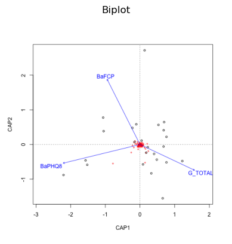

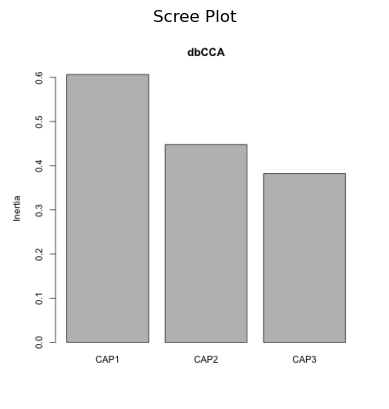

```python
import pandas as pd
import numpy as np
from sklearn.preprocessing import StandardScaler, OrdinalEncoder
from sklearn.impute import SimpleImputer
from rpy2.robjects import pandas2ri
import rpy2.robjects as robjects
from rpy2.robjects.packages import importr
from rpy2.robjects.vectors import StrVector
import matplotlib.pyplot as plt

# Load data
microbiome_data = pd.read_csv('/Users/nijat/Downloads/mappedTaxa.txt', delimiter='\t')
diet_data = pd.read_excel('/Users/nijat/Downloads/metadata.xlsx')

# Ensure UCSID is set as the index in diet_data
diet_data.set_index('UCSID', inplace=True)

# Prepare microbiome data
microbiome_pivot = microbiome_data.pivot_table(index='Sample', columns='OTU', values='value', fill_value=0)

# Define variables
numeric_variables = ['BaPHQ8', 'BaFCP', 'G_TOTAL']
categorical_variables = []

# Convert specified columns to numeric where applicable
for col in numeric_variables:
    diet_data[col] = pd.to_numeric(diet_data[col], errors='coerce')

# Merge dataframes on Sample and UCSID
combined_data = pd.merge(microbiome_pivot, diet_data[numeric_variables + categorical_variables], left_index=True, right_index=True, how='inner')

# Remove rows with any missing data
combined_data = combined_data.dropna()

# Split combined data into response and explanatory variables
response_data = combined_data.drop(columns=numeric_variables + categorical_variables)
explanatory_data = combined_data[numeric_variables + categorical_variables]

# Remove rows with all zeros in response_data
nonzero_rows = (response_data.T != 0).any()
response_data = response_data[nonzero_rows]
explanatory_data = explanatory_data[nonzero_rows]

# Convert categorical variables to category dtype
for col in categorical_variables:
    explanatory_data[col] = explanatory_data[col].astype('category')

# Impute missing values (NaNs) with the mean for numeric variables
imputer = SimpleImputer(strategy='median')
explanatory_data_imputed = explanatory_data.copy()
explanatory_data_imputed[numeric_variables] = imputer.fit_transform(explanatory_data[numeric_variables])

# Normalize (standardize) numeric explanatory variables
scaler = StandardScaler()
explanatory_data_scaled = explanatory_data_imputed.copy()
explanatory_data_scaled[numeric_variables] = scaler.fit_transform(explanatory_data_imputed[numeric_variables])

# Initialize R conversion
pandas2ri.activate()

# Ensure all data is numeric and reset the index to maintain DataFrame structure
response_data = response_data.apply(pd.to_numeric, errors='coerce').reset_index(drop=True)
explanatory_data_scaled = explanatory_data_scaled.apply(pd.to_numeric, errors='coerce').reset_index(drop=True)

# Convert DataFrames to R DataFrames
r_response_data = pandas2ri.py2rpy(response_data)
r_explanatory_data = pandas2ri.py2rpy(explanatory_data_scaled)

# Assign DataFrames to R global environment
robjects.globalenv['response_data'] = r_response_data
robjects.globalenv['explanatory_data'] = r_explanatory_data

# Perform db-CCA in R and extract results
result = robjects.r('''
library(vegan)

# Add a small constant to avoid zero values
response_data_001 <- response_data + 0.001

# Perform db-CCA using the Bray-Curtis distance measure
dbCCA <- capscale(response_data_001 ~ ., data = explanatory_data, dist = "bray",add='lingoes')

# Extract the loadings of the OTUs on the significant axes
loadings <- scores(dbCCA, display = "species")

# Extract the environmental scores
env_scores <- scores(dbCCA, display = "bp")

# Perform overall significance test
anova_result <- anova.cca(dbCCA)

# Perform permutation tests for individual environmental variables
anova_terms_result <- anova.cca(dbCCA, by = "terms", permu = 1000)

# Calculate the variance explained
variance_explained <- summary(dbCCA)$cont$importance[2, ]

# Calculate adjusted R-squared values
r_squared <- RsquareAdj(dbCCA)$r.squared
adj_r_squared <- RsquareAdj(dbCCA)$adj.r.squared

# Save biplot
png(filename="biplot.png")
plot(dbCCA)
dev.off()

# Save scree plot
png(filename="screeplot.png")
screeplot(dbCCA, bstick = TRUE)
dev.off()

# Return the results and scores
list(
  anova_result = anova_result,
  anova_terms_result = anova_terms_result,
  variance_explained = variance_explained,
  r_squared = r_squared,
  adj_r_squared = adj_r_squared,
  loadings = as.data.frame(loadings),
  env_scores = as.data.frame(env_scores)
)
''')

# Extract results
anova_result = result.rx2('anova_result')
anova_terms_result = result.rx2('anova_terms_result')
variance_explained = result.rx2('variance_explained')
r_squared = result.rx2('r_squared')
adj_r_squared = result.rx2('adj_r_squared')
loadings = result.rx2('loadings')
env_scores = result.rx2('env_scores')

# Convert R data frames to Pandas DataFrames
loadings_df = pandas2ri.rpy2py(loadings)
env_scores_df = pandas2ri.rpy2py(env_scores)

# Function to find top 10 OTUs for each axis
def find_top_otus(axis, n=20):
    return loadings_df[axis].abs().sort_values(ascending=False).head(n).index

# Find top 10 OTUs for CAP1 and CAP2
top_otus_cap1 = find_top_otus('CAP1')
top_otus_cap2 = find_top_otus('CAP2')

# Create DataFrames for the top OTUs
df_top_otus_cap1 = loadings_df.loc[top_otus_cap1, ['CAP1']]
df_top_otus_cap2 = loadings_df.loc[top_otus_cap2, ['CAP2']]

# Display the DataFrames
print("Top OTUs for CAP1:")
print(df_top_otus_cap1)

print("\nTop OTUs for CAP2:")
print(df_top_otus_cap2)

# Display overall results
print("Overall Significance Test:")
print(anova_result)

print("\nPermutation Tests for Individual Environmental Variables:")
print(anova_terms_result)

print("\nVariance Explained:")
print(variance_explained)

print("\nR-squared:")
print(r_squared)

print("\nAdjusted R-squared:")
print(adj_r_squared)

# Display plots
biplot_img = plt.imread('biplot.png')
plt.imshow(biplot_img)
plt.axis('off')
plt.title('Biplot')
plt.show()

screeplot_img = plt.imread('screeplot.png')
plt.imshow(screeplot_img)
plt.axis('off')
plt.title('Scree Plot')
plt.show()
```

## Results

The distance-based Canonical Correspondence Analysis (db-CCA) revealed significant insights into the microbial community structure influenced by specific environmental variables. **Blautia wexlerae** emerged as the most influential operational taxonomic unit (OTU) across both CAP1 and CAP2, with strong negative loadings of -0.777896 and -0.548639, respectively. This suggests that **Blautia wexlerae** is associated with the explanatory variables, playing a pivotal role in the microbial dynamics.

The overall model was highly significant, with a p-value of less than 0.001, and an adjusted R-squared of 0.1165, indicating that the environmental variables **BaPHQ8**, **BaFCP**, and **G_TOTAL** explain a considerable portion of the variance in the microbial data. The permutation tests for these individual variables further underscored their importance, with **BaPHQ8** (p = 0.002), **BaFCP** (p = 0.017), and **G_TOTAL** (p = 0.005) all contributing significantly to the model. This highlights the strong influence of these variables on the microbial community structure.

Moreover, the variance explained by the model components reflects the complex and multifaceted nature of the microbial ecosystem. The total R-squared of 0.2317 indicates that the selected environmental variables account for a substantial portion of the observed variability. These findings underscore the critical role of **BaPHQ8**, **BaFCP**, and **G_TOTAL** in modulating the microbial composition, providing a robust understanding of how specific environmental factors interact with microbial communities.